# TUT01 - Vale a pena usar a média para selecionar seus jogadores?

## Criar banco de dados

```r
treino <- cartola %>%
  filter(!(Rodada == 20 & ano == 2017))

validacao <- cartola %>%
  filter(Rodada == 20 & ano == 2017)
```

#### Comentário

Pronto, agora que fizemos a divisão, precisamos calcular a média de desempenho dos jogadores. Para calcular, usamos novamente o pacote *dplyr* numa cadeia de comandos. Vamos também criar a variável jogos, que é a quantidade de partidas.

### Preparar dados

```r
by_player <- treino %>%
                group_by(AtletaID) %>%
                summarise(media = mean(Pontos), mediana = median(Pontos),
                          jogos = n_distinct(Rodada)- 1)
```

Vamos agora ver como a média dos jogadores se distribui usando novamente um histograma.

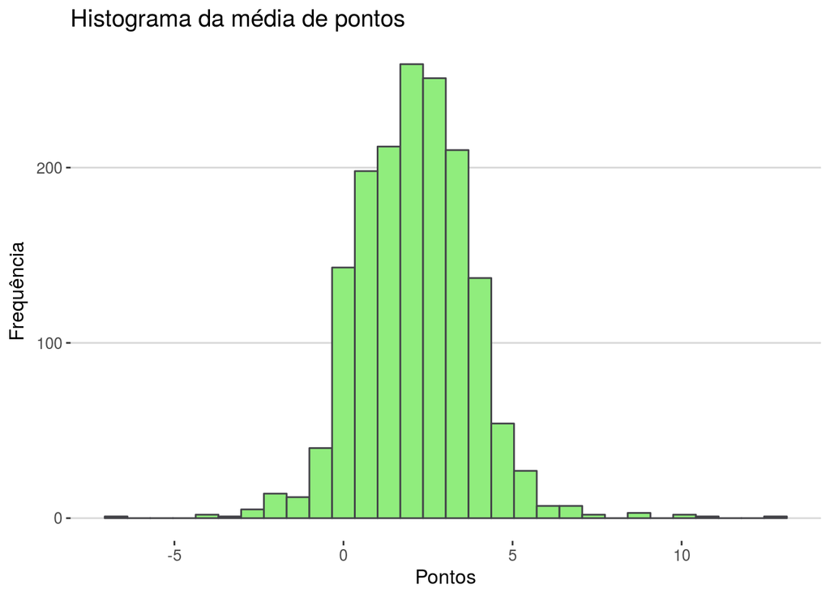

```r
ggplot(data = by_player, aes(media)) +
  geom_histogram(bins = 30, fill = ggthemes_data$hc$palettes$default[3], colour = ggthemes_data$hc$palettes$default[2]) +
  theme_hc() +
  labs(title = "Histograma da média de pontos", x = "Pontos", y = "Frequência")
```

#### Comentário

Através do nosso histograma, podemos observar que a distribuição dos pontos é razoavelmente simétrica. No entanto, sabemos que o número de jogos pode influenciar a média de pontos. Talvez, jogadores que joguem menos e têm status de provável pontuam menos que aqueles que entram e possuem melhor pontuação. Lembre-se aqui, que a quantidade de pontos do cartola não necessariamente caracterizam bons jogadores (Cartola != Futebol real). Para verificarmos plotamos as médias em gráficos violino.

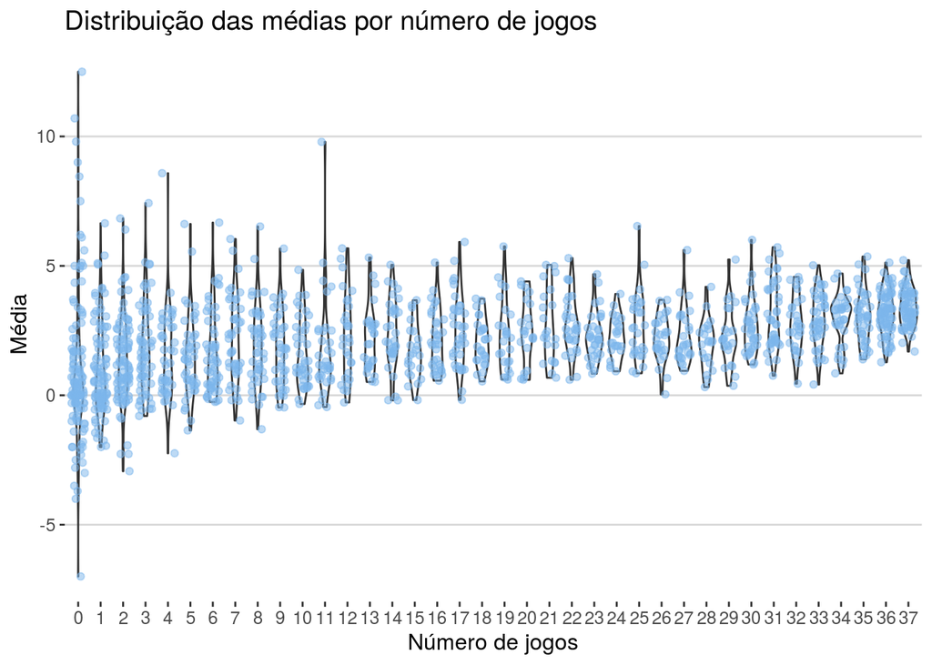

```r
ggplot(data = by_player, aes(y = media, factor(jogos))) +
  geom_violin() + geom_jitter(width = .3, alpha = .5, colour = "#7cb5ec") +
  theme_hc() +
  labs(title = "Distribuição das médias por número de jogos", x = "Número de jogos", y = "Média")
```

## E a média, vale a pena?

Vamos agora ao que interessa, comparar se a média é um bom indicador (modelo) para prever o desempenho dos jogadores.

### RMSE e MAE

Como fazemos isso? O Erro Médio Quadrático (RMSE, do inglês, Root Mean Square Error) e Erro Absoluto da Média (MAE, do inglês, Mean Absolute Error) são métricas usadas para avaliar modelos de predição com desfecho numérico - e.g., pontuação.

Vamos, então avaliar o quão bem a média é capaz de prever os resultados da nova rodada. Antes disso, precisamos preparar os dados.

```r
# Vamos preparar os dados para fazer a comparação.
# 1. Criamos os dados por jogador da rodada 11
round20_player <- validacao %>%
                group_by(AtletaID) %>%
                summarise(pontos = mean(Pontos))
# 2. Concatenamos (join) os resultados da nossa predição com os dados da rodada 20 pela id do jogador
dados <- left_join(by_player, round20_player, by = "AtletaID")
```

```r
dados <- mutate(dados, erro_media = media - pontos, erro_mediana = mediana - pontos)

# Função Root Mean Squared Error
RMSE <- function(error)
{
    sqrt(mean(error^2, na.rm = TRUE))
}

# Função Mean Absolute Error
MAE <- function(error)
{
    mean(abs(error), na.rm = TRUE)
}

# Comparar resultados da média e mediana
# RMSE
print(sapply(dados[, c("erro_media","erro_mediana")], RMSE))
```

```
##   erro_media erro_mediana
##     4.122707     4.199233
```

```r
# MAE
print(sapply(dados[, c("erro_media","erro_mediana")], MAE))
```

```
##   erro_media erro_mediana
##     3.230416     3.157425
```

## Próximo tutorial

Iremos comparar a média contra outros modelos, tentando melhorar nossas previsões. Até o segundo tutorial! :)

# Dados da sessão

```
##  setting  value
##  version  R version 3.4.0 (2017-04-21)
##  system   x86_64, linux-gnu
##  ui       RStudio (1.0.143)
##  language (EN)
##  collate  en_US.UTF-8
##  tz       America/Sao_Paulo
##  date     2017-07-03
```

```
## Packages -----------------------------------------------------------------
```

[output not shown]